# Avaliação Continuada - Aula 6

**Execute a célula a seguir para importar as bibliotecas de que vamos precisar e criar a variável `taxis` com nossa base de dados.**

```python
# Importando a biblioteca seaborn
import seaborn as sns
import matplotlib.pyplot as plt

# Carregando a base de dados 'taxis'
taxis = sns.load_dataset("taxis")

taxis.head()
```

|  | pickup | dropoff | passengers | distance | fare | tip | tolls | total | color | payment | pickup_zone | dropoff_zone | pickup_borough | dropoff_borough |
| --- | --- | --- | --- | --- | --- | --- | --- | --- | --- | --- | --- | --- | --- | --- |
| 0 | 2019-03-23 20:21:09 | 2019-03-23 20:27:24 | 1 | 1.60 | 7.0 | 2.15 | 0.0 | 12.95 | yellow | credit card | Lenox Hill West | UN/Turtle Bay South | Manhattan | Manhattan |
| 1 | 2019-03-04 16:11:55 | 2019-03-04 16:19:00 | 1 | 0.79 | 5.0 | 0.00 | 0.0 | 9.30 | yellow | cash | Upper West Side South | Upper West Side South | Manhattan | Manhattan |

### Sobre os dados

No exercício de hoje, vamos utilizar as seguintes variáveis:

- `color`: cor do taxi que fez a corrida (pode ser "yellow" ou "green").
- `tip`: valor da gorjeta dada ao motorista, em dólares ($).

Nosso objetivo é verificar se há alguma diferença significativa nas gorjetas recebidas por taxis amarelos e verdes.

### Exercício de hoje - Parte 1

Utilize a função `sns.boxplot()` para criar um gráfico boxplot que mostre a distribuição gorjetas (coluna `"tip"`) recebidas por taxis amarelos e verdes (coluna `"color"`).

Após escrever a linha de código de sua resposta, execute a célula para mostrar o gráfico a partir da base `taxis`.

**Importante: antes de executar o código da sua resposta, não deixe de executar a célula de código que está no início deste caderno, que importa as bibliotecas e carrega os dados.**

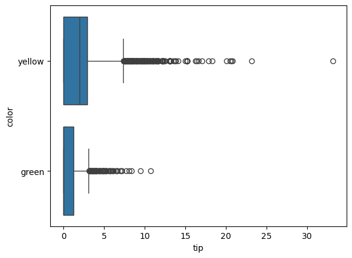

```python
# Escreva sua resposta abaixo e execute a célula para gerar o gráfico
sns.boxplot(
    x="tip", # nesse caso a escolha dos eixos de cada variável é livre.
    y="color",
    data=taxis
)
```

### Exercício de hoje - Parte 2

Realmente os taxis amarelos parecem estar recebendo mais gorjeta do que os taxis verdes! Para mostrar esse resultado interessante, produza novamente o mesmo gráfico, mas agora você deve customizá-lo da seguinte maneira:

- aumente o tamanho das dimensões do gráfico usando a função: `plt.subplots()` (uma sugestão é usar: `figsize=(12,6)`)
- adicione ao gráfico o seguinte título: `"Yellow cabs are getting more tips!"`,
- adicione rótulos apropriados aos eixos `x` e `y` do gráfico.

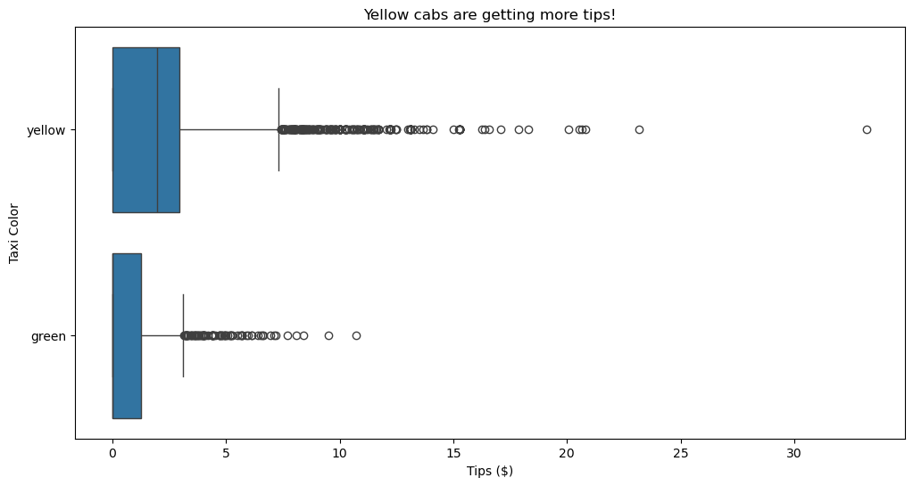

```python
# Escreva sua resposta abaixo e execute a célula para gerar o gráfico
fig, ax = plt.subplots(figsize=(12, 6)) # os valores de figsize podem ser diferentes

sns.boxplot(
    x="tip", # nesse caso a escolha dos eixos de cada variável é livre.
    y="color",
    data=taxis,
    ax=ax
)

ax.set_title("Yellow cabs are getting more tips!")
ax.set_xlabel("Tips ($)")
ax.set_ylabel("Taxi Color")

# se o aluno adicionar outras customizações (por exemplo cor), não há problema
```